# STAT 118: Finding a Dataset Worth Investigating

Final Project — Class 1

## Introduction to your Final Project

For your final project, you will choose your own dataset(s), develop a research question, conduct an investigation, and communicate your findings in a final report.

A few things to keep in mind:

- **Choose something you’re genuinely interested in.** You’ll be spending several weeks working with these data.
- **You don’t need a research question yet.** Your question will develop as you explore the data.
- **Your project should be an investigation**, not simply a collection of unrelated figures.
- **You’ll develop your project over time.** We’ll have opportunities for discussion, feedback, and revision throughout the remaining classes.

## Good Analysis Starts with Good Data

Throughout this semester, I’ve given you datasets to work with. I’ve often told you which variables to examine, what questions to answer, and sometimes even which analyses to perform. That means I’ve been making a lot of important decisions for you. But those decisions are a fundamental part of data science. Before we can analyze data, we need to figure out what data are available, whether they’re appropriate for our purposes, and whether we can trust them.

Finding a dataset isn’t just a preliminary step before the real work begins. Choosing and evaluating data is part of the real work. The data we choose determine what questions we can answer, what patterns we can investigate, and what conclusions we can reasonably draw.

For your final project, you’ll take responsibility for the entire process of conducting a data science investigation, from finding data and developing questions to analyzing results and communicating your findings. Today we’re starting with the first two:

1. Finding data: Where can we find data relevant to something we want to understand?
2. Evaluating data: How can we decide whether those data are useful, reliable, and appropriate for an investigation?

Today, we will be spending some time at the very beginning. Partly because this is a step that has largely been hidden from you until now, both in this class and very likely in other classes as well. And because many of the decisions you make early on in data selection will haunt you if you don’t give them proper attention. This is the burden and the opportunity of being responsible for the full pipeline.

## What makes a good dataset?

Not every dataset is a good choice for this project. Before committing to one, we need to consider whether it is interesting, accessible, understandable, and capable of supporting a meaningful investigation.

### Five criteria for evaluating datasets

**1. Interest — Do I care about these data?**

- Am I genuinely curious about the topic?
- Would I enjoy spending several weeks investigating it?

**2. Accessibility — Can I get the data?**

- Can I download the actual data, rather than just looking at someone else’s figures or summaries?
- Are the data available in a format I can open and work with in R?

**3. Understanding — Can I make sense of the data?**

- What does one observation (row) represent?
- What do the variables mean?
- Is there documentation explaining the data and how they were collected?

**4. Analytical potential — Is there enough to investigate?**

- Are there meaningful differences across groups, locations, or time?
- Are there multiple variables I could compare or relate?
- Can I imagine more than one interesting question?

**5. Feasibility — What might prevent me from using these data successfully?**

- Is the dataset a reasonable size?
- Does the structure make sense?
- Is there missing information or unclear categories?
- Can I imagine working with it using the R skills we’ve learned?

**Remember:** A dataset doesn’t need to be perfect. Some cleaning and troubleshooting are expected. The question is whether the challenges are manageable.

## Explore potential datasets

I have compiled a [LARGE list of potential data sources](https://cschine.github.io/my_class_website/courses/STAT118/final_project/ready/Data_Sources.html). Use the list I gave you or explore other sources that interest you.

In class you worked in groups to identify potentially interesting datasets. Let’s investigate some of the datasets you found and assess them according to our criteria for a good dataset.

We looked at 2 datasets. The first was WNBA shooting statistics which required quite a bit of cleaning and manipulation after finding the dataset.

### WNBA data

https://www.basketball-reference.com/wnba/years/2025_shooting.html

I tried a few of the other export options that were available at the top of the page. The “Get as Excel Workbook” exports a `.xls` file. It wasn’t as simple as reading it straight in from the excel file, which appeared to be corrupted somehow. I opened it in Excel and resaved it as a `.csv` and then imported it.

```r
library(tidyverse)
WNBA_data <- read_csv("~/Dropbox/!Middlebury/Teaching/my_class_website/courses/STAT118/final_project/data/sportsref_download.csv", skip=1)

head(WNBA_data)
```

```
# A tibble: 6 × 29
  Player       Tm    Pos   G...4 MP...5 G...6 MP...7 `FG%` Dist. ...10 `2P...11`
  <chr>        <chr> <chr> <dbl>  <dbl> <dbl>  <dbl> <dbl> <dbl> <lgl>     <dbl>
1 Maya Caldwe… ATL   G        41    760    41    760 0.426  16.7 NA        0.436
2 Jordin Cana… ATL   G        28    783    28    783 0.396  11.5 NA        0.685
3 Nia Coffey   ATL   F        44    455    44    455 0.374  15   NA        0.442
4 Allisha Gray ATL   G        42   1451    42   1451 0.451  14.7 NA        0.533
5 Brittney Gr… ATL   C        39    810    39    810 0.518   7.9 NA        0.937
6 Naz Hillmon  ATL   F        44   1122    44   1122 0.463  14.8 NA        0.45
# ℹ 18 more variables: `0-3...12` <dbl>, `10-Mar...13` <dbl>,
#   `16-Oct...14` <dbl>, `16-3P...15` <dbl>, `3P...16` <dbl>, ...17 <lgl>,
#   `2P...18` <dbl>, `0-3...19` <dbl>, `10-Mar...20` <dbl>,
#   `16-Oct...21` <dbl>, `16-3P...22` <dbl>, `3P...23` <dbl>, ...24 <lgl>,
#   `2P...25` <dbl>, `3P...26` <dbl>, ...27 <lgl>, `%3PA` <dbl>, `3P%` <dbl>
```

You can see that the column names are still a complete mess and will need to be cleared up manually probably.

But we can start to do some basic things with the data like look at distributions of different variables. The histogram below shows the distribution of Field Goal % across all of the players in the dataset.

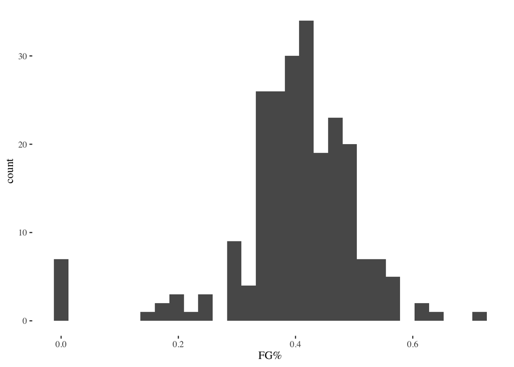

```r
library(ggthemes)
WNBA_data |>
  ggplot(aes(x=`FG%`)) + # note the ` ` around the FG%, this is necessary with special characters or spaces. If I was going to continue working with these data, I would change this column name so that I don't have to keep doing this.
  geom_histogram() +
  theme_tufte()
```

Having looked at this I am very curious which players have the highest and lowest `FG%`. Here are the three highest:

```r
WNBA_data |>
  arrange(desc(`FG%`)) |>
  slice(1:3) |>
  select(Player, `FG%`)
```

```
# A tibble: 3 × 2
  Player               `FG%`
  <chr>                <dbl>
1 Mackenzie Holmes     0.714
2 Jessica Shepard      0.638
3 Cheyenne Parker-Tyus 0.625
```

To get at the lowest I decided to filter for all players with an `FG%` of zero:

```r
WNBA_data |>
  filter(`FG%`==0) |>
  select(Player, `FG%`)
```

```
# A tibble: 7 × 2
  Player          `FG%`
  <chr>           <dbl>
1 Yvonne Anderson     0
2 Marième Badiane     0
3 Serena Sundell      0
4 Aerial Powers       0
5 Grace Berger        0
6 Bree Hall           0
7 Sika Koné           0
```

So, according to our criteria, this dataset is **accessible** (reasonably), **understandable** (with a little work, some of the variables are a touch confusing), there is a lot of **analytical potential**, especially if you go after multiple years, and it is **feasible** to work with (not too big, no missing data, etc.). SO, I would call this a good data set, or atleast a good place to start, with a lot more data on the same topic available on the website.

### Moods and Activities in Music

The second dataset that we looked at came from the website:

https://reshare.ukdataservice.ac.uk/852024/

And was collected by folks at Durham University in the UK. It contains “annotations of music in terms of moods music may express and activities that music might fit”. It downloads as a `.zip` file and unpacks to 11 different `.csv` files that each contain a different aspect of the dataset. It comes with a very helpful [`README`](https://reshare.ukdataservice.ac.uk/852024/3/ReadMe.txt), that explains each of the different datasets and what they contain.

This one is a bit complicated because of how it is distributed across so many files. I’m going to open the `bg_activities_musical.csv` file which contains answers from each user to the question, “How important is music to you in the following activities?” The user assigns a value of 1-5 to each activity.

```r
activities <- read_csv("courses/STAT118/final_project/data/moods_and_activities_in_music/bg_activities_musical.csv")

# to get the number of rows and columns
dim(activities)
```

```
[1] 2508   10
```

```r
# to get all of the column names
colnames(activities)
```

```
 [1] "userid"                   "activity.daily_routines"
 [3] "activity.emotional"       "activity.entertainment"
 [5] "activity.intellectual"    "activity.live_music"
 [7] "activity.music_listening" "activity.on_the_move"
 [9] "activity.physical"        "activity.social"
```

So, I have 2,508 observations and 10 variables. The names of the columns are pretty descriptive and give me a decent idea of what activities are being surveyed.

I’m going to take a different route than previously and pivot this dataset longer and then create a stack of ridgeline plots to look at how the distribution changes depending on the activity.

Here we go:

```r
activities_long <- activities |>
  pivot_longer(cols=starts_with("activity"),
               names_to="activity",
               values_to="value",
               names_prefix="activity.")

head(activities_long)
```

```
# A tibble: 6 × 3
  userid activity        value
   <dbl> <chr>           <dbl>
1      5 daily_routines      4
2      5 emotional           5
3      5 entertainment       2
4      5 intellectual        3
5      5 live_music          5
6      5 music_listening     5
```

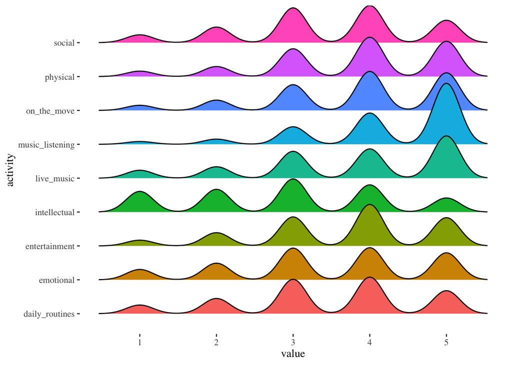

```r
library(ggridges)
activities_long |>
  ggplot(aes(x=value, y=activity, fill=activity)) +
  geom_density_ridges() +
  theme_tufte() +
  theme(legend.position="none") # suppress legend
```

Ew. That it terrible. I’m going to do something similar but a histogram instead.

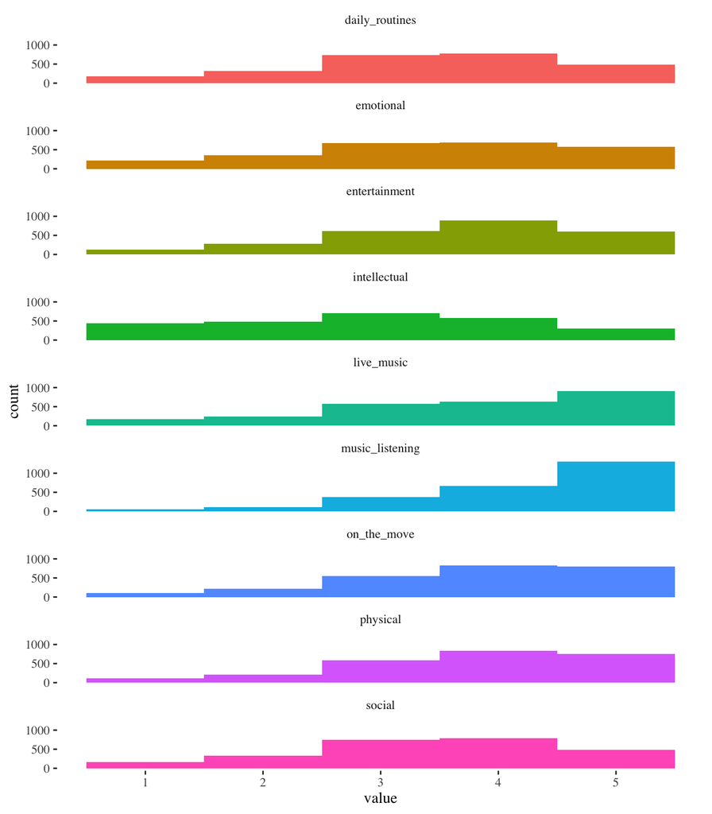

```r
activities_long |>
  ggplot(aes(x=value, fill=activity)) +
  geom_histogram(bins=5) +
  facet_wrap(~activity, ncol=1) +
  theme_tufte() +
  theme(legend.position="none")
```